# MWC Data Exploration

Joseph Zuccarelli

10/27/2020

### Datasets

Our first dataset is a collection of summary information such as sex, race, age, and standardized test scores for 6,737 cadets from the Class of 2018 to the Class of 2023.

```r
#AMS Data
AMSdata <- read.csv("AMSData_anonymous.csv")
AMSdata %>%
  head()
```

|  | gradYear | subjectID | CEER | satMath | satVrbl | satWrite | actComp | actEng | actMath | actRead | actSci | actWrite | enterYear | sex | enterAge | race | gradeEN101 | gradeEN152 | gradeHI105 | gradeSS202 | cqpa | acadMajor |
| --- | --- | --- | --- | --- | --- | --- | --- | --- | --- | --- | --- | --- | --- | --- | --- | --- | --- | --- | --- | --- | --- | --- |
| 1 | 2018 | 0ec595 | 528 | 560 | 540 | 570 | 24 | 26 | 26 | 21 | 24 | 25 | 2018 | M | 19 | B | NA | NA | C | NA | 2.467 | Chemical Engineering Major |
| 2 | 2018 | 8e9f53 | 688 | 740 | 690 | 640 | 35 | 35 | 34 | 36 | 34 | 31 | 2018 | M | 18 | W | NA | NA | NA | NA | 3.671 | Chemical Engineering Major w/ Honors |
| 3 | 2018 | a942c1 | 623 | 740 | 520 | 610 | NA | NA | NA | NA | NA | NA | 2018 | M | 17 | A | NA | NA | C+ | NA | 3.313 | Chemical Engineering Major |
| 4 | 2018 | c6634d | 685 | 710 | 660 | 690 | 31 | 30 | 33 | 33 | 29 | 28 | 2018 | F | 18 | W | NA | NA | NA | NA | 3.480 | Chemical Engineering Major |
| 5 | 2018 | 4978a0 | 603 | 700 | 620 | 640 | NA | NA | NA | NA | NA | NA | 2018 | F | 18 | B | NA | NA | NA | NA | 2.775 | Chemical Engineering Major |
| 6 | 2018 | a1f580 | 759 | 750 | 780 | 680 | 32 | 28 | 34 | 33 | 34 | 24 | 2018 | M | 18 | W | NA | NA | NA | NA | 3.194 | Chemical Engineering Major |

Our second dataset is a collection of 3,351 recorded grades for culminating writing assignments in core courses.

```r
#SWE Data
SWEdata <- read.csv("AMS SWE Data (anonymous - asof13Feb).csv")
SWEdata %>%
  head()
```

|  | subjectID | eventYear | eventSemest | courseCode | instructor | gradYear | acadMajor | sweGrade | eventGrade | isComplete |
| --- | --- | --- | --- | --- | --- | --- | --- | --- | --- | --- |
| 1 | ead52c | 2018 | 1 | DS320 I 3 | LEACH, RYAN | 2017 | Management | NA | Â Â 0.00 | InComplete |
| 2 | 880000 | 2018 | 1 | HI108A J 2 | MUKERJEE, ANIL | 2017 | Law and Legal Studies | NA | Â Â 83.00 | InComplete |
| 3 | 49f25c | 2018 | 1 | LW403 C 19 | YON, RACHEL | 2017 | Management | NA | Â Â 0.00 | InComplete |
| 4 | 6f443b | 2018 | 1 | LW403 C 8 | HARTLEY, CHRISTOPHER | 2017 | Environmental Geography | NA | Â Â 0.00 | InComplete |
| 5 | cbcd97 | 2018 | 1 | LW403 C 8 | HARTLEY, CHRISTOPHER | 2017 | Human Geography | NA | Â Â 0.00 | InComplete |
| 6 | b68313 | 2018 | 1 | LW403 D 11 | KRAMER, MICHAEL | 2017 | Management | NA | Â Â 0.00 | InComplete |

Our third dataset is a collection of 22,077 visitation records from the Mounger Writing Center. This dataset includes the date of each appointment and the course associated with the writing assignment reviewed during each appointment.

```r
#MWC Data
MWCdata <- read.csv("MWC_clients (asof13Feb).csv")
MWCdata %>%
  head()
```

|  | subjectID | sessionDate | courseCode |
| --- | --- | --- | --- |
| 1 | 0945af | 12/12/2019 | ELECTIVE: Social Sciences |
| 2 | bd8ba9 | 12/12/2019 | EN101: Composition |
| 3 | a1ae07 | 12/12/2019 | SS202: American Politics |
| 4 | 7b09e7 | 12/12/2019 | ELECTIVE: Social Sciences |
| 5 | 090ce1 | 12/12/2019 | ELECTIVE: History |
| 6 | df9038 | 12/11/2019 | ELECTIVE: English & Philosophy |

Our fourth data set is a combination of the MWC data and the SWE data.

```r
#MWC & SWE Data
MWCcombinedSWEdata <- read.csv("combined_data.csv")
MWCcombinedSWEdata %>%
  head()
```

|  | subjectID | courseCode | eventYear | eventSemest | semID | eventGrade | sweGrade | didAttend | sessionDate | instructor | acadMajor | gradYear |
| --- | --- | --- | --- | --- | --- | --- | --- | --- | --- | --- | --- | --- |
| 1 | 6f443b | PL300 | 2018 | 1 | 2018-1 | 73.00 | 2 | 0 | NA | BORLAND, JOHN | Environmental Geography | 2017 |
| 2 | fe5c23 | SS307 | 2018 | 1 | 2018-1 | 79.20 | 3 | 0 | NA | PARRISH, BRANDON | Law and Legal Studies | 2017 |
| 3 | b5f51a | SS307 | 2018 | 1 | 2018-1 | 78.00 | 3 | 0 | NA | DEEP, ALEX | Interdisciplinary Science | 2017 |
| 4 | 780281 | EN300 | 2018 | 1 | 2018-1 | 91.56 | 4 | 0 | NA | SAMET, ELIZABETH | English | 2018 |
| 5 | 5bebd2 | EN300 | 2018 | 1 | 2018-1 | 78.67 | 3 | 0 | NA | SAMET, ELIZABETH | English | 2018 |
| 6 | 317025 | EN300 | 2018 | 1 | 2018-1 | 51.56 | 2 | 0 | NA | SAMET, ELIZABETH | English | 2018 |

Our fifth data set is the combined data set along with imputed data concerning the subject.

```r
#Imputed Data
imputedDataOriginal <- read.csv("imputed_data.csv")
imputedDataOriginal %>%
  head()
```

|  | subjectID | courseCode | eventYear | eventSemest | semID | eventGrade | sweGrade | didAttend | sessionDate | instructor | gradYear | totalVisits | sex | enterAge | race | CEER | satMath | satVrbl | satWrite | actComp | actEng | actMath | actRead | actWrite | enterYear | cqpa | acadMajor.y |
| --- | --- | --- | --- | --- | --- | --- | --- | --- | --- | --- | --- | --- | --- | --- | --- | --- | --- | --- | --- | --- | --- | --- | --- | --- | --- | --- | --- |
| 1 | 011fd7 | PL300 | 2019 | 2 | 2019-2 | 77.5 | 2 | 0 | NA | CLARK, MATTHEW | 2020 | 0 | M | 18 | H | 587 | 620 | 690 | 680 | 27 | 26 | 29 | 27 | 26 | NA | NA | NA |
| 2 | 02e13a | PL300 | 2019 | 2 | 2019-2 | 85.0 | 3 | 0 | NA | YASTRZEMSKY, JAMES | 2020 | 0 | M | 18 | A | 695 | 780 | 660 | 720 | 33 | 34 | 32 | 33 | 34 | NA | NA | NA |
| 3 | 040dad | PL300 | 2019 | 2 | 2019-2 | 87.5 | 2 | 0 | NA | CARSON, JEFFREY | 2020 | 0 | M | 18 | H | 547 | 570 | 510 | 470 | 24 | 23 | 26 | 22 | 21 | NA | NA | NA |
| 4 | 04c5fb | PL300 | 2019 | 2 | 2019-2 | 90.0 | 3 | 0 | NA | CARSON, JEFFREY | 2020 | 0 | F | 18 | W | 630 | 620 | 660 | 620 | 30 | 34 | 29 | 31 | 28 | 2020 | 3.718 | Systems and Decision Sciences Major |
| 5 | 05b24e | PL300 | 2019 | 2 | 2019-2 | 79.0 | 3 | 0 | NA | SWAIN, JORDON | 2020 | 0 | M | 18 | W | 526 | 630 | 530 | 550 | 25 | 23 | 28 | 23 | 24 | 2020 | 2.165 | Engineering Psychology Major |
| 6 | 0616c5 | PL300 | 2019 | 2 | 2019-2 | 80.0 | 2 | 0 | NA | CARSON, JEFFREY | 2020 | 0 | F | 19 | W | 653 | 640 | 590 | 650 | 31 | 35 | 27 | 34 | 31 | NA | NA | NA |

Note that we are only concerned with three courses (and their advanced versions): English Composition, American History, and International Relations. We also do not want to include observations in which the event grade was a zero.

```r
#Filtering by Course & Grade
imputedDataFiltered <- imputedDataOriginal %>%
  filter(courseCode == "EN101"|courseCode == "EN151"|courseCode == "HI105"|courseCode =="HI155"|courseCode =="SS307"|courseCode      =="SS357") %>%
  filter(eventGrade > 0)
```

```r
#Adding the categorical variable MWCvisits
imputedDataFiltered <- imputedDataFiltered %>%
  mutate(MWCvisits = ifelse(totalVisits == 0, "Never",
                            ifelse(totalVisits == 1, "Once",
                                   ifelse(totalVisits > 1, "Multiple Times", NA))))

#Reorder levels
imputedDataFiltered$modMWCvisits <- factor(imputedDataFiltered$MWCvisits, levels=c("Multiple Times","Once","Never"))
```

Note that we want to combine observations from the advanced and regular versions of the three courses involved in our study. We can assume that this will have no major effect, as both the advanced and regular versions of each course culminate with the same signature writing event.

```r
#Combining observations from advanced and regular sessions
imputedDataFiltered <- imputedDataFiltered %>%
  mutate(course = ifelse(courseCode == "EN101" | courseCode == "EN151", "EN101/151",
                            ifelse(courseCode == "HI105" | courseCode == "HI155", "HI105/155",
                                   ifelse(courseCode == "SS307" | courseCode == "SS357", "SS307/357", NA))))
```

Note that we are curious as to how many cadets in the data set visited the MWC for more than one of the courses involved in the study, as this would affect the independence condition.

```r
#Number of Course Visits by Subject
courseVisitsDF <- imputedDataFiltered %>%
  count(subjectID) %>%
  arrange(desc(n)) %>%
  rename(CourseVisits = n)

courseVisitsDF
```

| subjectID | CourseVisits |
| --- | --- |
| fb3333 | 3 |
| 0a6bad | 2 |
| 0a95ab | 2 |
| 0e93bd | 2 |
| 133387 | 2 |
| 17313f | 2 |
| 193d3e | 2 |
| 1bca3e | 2 |
| 1c6bad | 2 |
| 1e6fd7 | 2 |

[output cut: 2580 more lines]

We see that multiple subjects are included in the data set more than once.

```r
#Number of Subjects that visited for # different courses
courseVisitsDF %>%
  count(CourseVisits) %>%
  arrange(desc(CourseVisits))
```

| CourseVisits | n |
| --- | --- |
| 3 | 1 |
| 2 | 76 |
| 1 | 2513 |

### Summary Information

The following table displays the number of MWC visits by semester. Notice that each year more cadets are visiting the writing semester. Also notice that slightly more cadets tend to visit the writing center during first semester.

```r
#MWC Visits by semester
MWCvisitcountsem <- MWCcombinedSWEdata %>%
  group_by(semID) %>%
  filter(semID == "2016-2" | semID == "2017-1" | semID == "2017-2" |semID == "2018-1" |semID == "2018-2" |semID == "2019-1" |semID   == "2019-2") %>%
  filter(didAttend == 1) %>%
  count() %>%
  rename(visits = n)

MWCvisitcountsem
```

| semID | visits |
| --- | --- |
| 2016-2 | 123 |
| 2017-1 | 299 |
| 2017-2 | 183 |
| 2018-1 | 489 |
| 2018-2 | 422 |
| 2019-1 | 604 |
| 2019-2 | 550 |

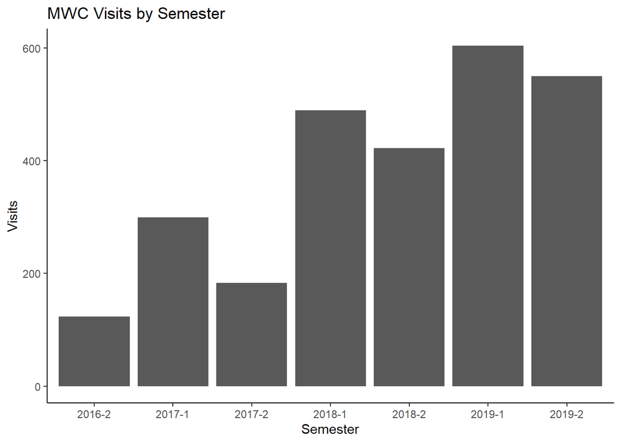

```r
#MWC Visits by Semester
MWCvisitcountsem %>%
  ggplot(aes(y=visits,x=semID)) +
  geom_bar(stat = 'identity') +
  labs(x = "Semester", y = "Visits") +
  ggtitle("MWC Visits by Semester") +
  theme_classic()
```

The following table indicates the total number of MWC visits by course. We see that the five most popular courses are English Composition, English Literature, American History, American Politics, and International Relations.

```r
#MWC Visits by course
MWCvisitcountcourse <- MWCcombinedSWEdata %>%
  filter(courseCode != "NA") %>%
  filter(didAttend == 1) %>%
  group_by(courseCode) %>%
  count(sort = TRUE) %>%
  rename(visits = n)

MWCvisitcountcourse
```

| courseCode | visits |
| --- | --- |
| EN101 | 279 |
| EN102 | 179 |
| HI101 | 111 |
| SS202 | 99 |
| SS307 | 95 |
| PY201 | 85 |
| PL100 | 79 |
| HI302 | 52 |
| HI105 | 44 |
| HI108 | 33 |

[output cut: 26 more lines]

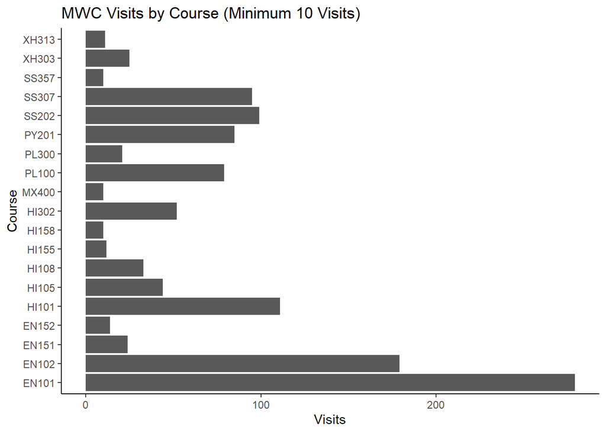

```r
#MWC Visits by Course
MWCvisitcountcourse %>%
  filter(visits >= 10 ) %>%
  ggplot(aes(y=visits,x=courseCode)) +
  geom_bar(stat = 'identity') +
  labs(x = "Course", y = "Visits") +
  ggtitle("MWC Visits by Course (Minimum 10 Visits)") +
  coord_flip() +
  theme_classic()
```

### Preliminary Analysis

The following table provides some demographic information concerning cadets from each attendance level. Note that the average event grade is higher for cadets who visited the writing center compared to those who did not. Also note that the average event grade is also slightly higher for cadets who visited the writing center multiple times compared to those who only visited the writing center once.

```r
#Table for Demographic Information
table1(~eventGrade + sweGrade + race + sex + enterAge | as.factor(modMWCvisits),data = imputedDataFiltered)
```

|  | Multiple Times (N=95) | Once (N=207) | Never (N=2366) | Overall (N=2668) |
| --- | --- | --- | --- | --- |
| eventGrade |  |  |  |  |
| Mean (SD) | 83.9 (8.64) | 83.0 (9.06) | 81.7 (8.94) | 81.9 (8.95) |
| Median [Min, Max] | 85.0 [60.0, 100] | 83.1 [58.0, 100] | 81.6 [18.0, 100] | 81.6 [18.0, 100] |
| sweGrade |  |  |  |  |
| Mean (SD) | 3.01 (0.722) | 3.01 (0.668) | 3.00 (0.644) | 3.00 (0.649) |
| Median [Min, Max] | 3.00 [1.00, 4.00] | 3.00 [1.00, 4.00] | 3.00 [1.00, 4.00] | 3.00 [1.00, 4.00] |
| race |  |  |  |  |
| A | 15 (15.8%) | 25 (12.1%) | 190 (8.0%) | 230 (8.6%) |
| B | 18 (18.9%) | 35 (16.9%) | 319 (13.5%) | 372 (13.9%) |
| H | 4 (4.2%) | 14 (6.8%) | 226 (9.6%) | 244 (9.1%) |
| N | 1 (1.1%) | 2 (1.0%) | 31 (1.3%) | 34 (1.3%) |
| O | 2 (2.1%) | 3 (1.4%) | 35 (1.5%) | 40 (1.5%) |
| W | 55 (57.9%) | 128 (61.8%) | 1565 (66.1%) | 1748 (65.5%) |
| sex |  |  |  |  |
| F | 29 (30.5%) | 71 (34.3%) | 507 (21.4%) | 607 (22.8%) |
| M | 66 (69.5%) | 136 (65.7%) | 1859 (78.6%) | 2061 (77.2%) |
| enterAge |  |  |  |  |
| Mean (SD) | 18.4 (0.870) | 18.3 (1.06) | 18.3 (0.990) | 18.3 (0.992) |
| Median [Min, Max] | 18.0 [17.0, 21.0] | 18.0 [17.0, 22.0] | 18.0 [17.0, 23.0] | 18.0 [17.0, 23.0] |

We now perform several chi-squared tests and one-way ANOVA tests in order to examine the relationship between MWC visits and each of the covariates in the table.

```r
#ANOVA Test (MWC Visits & Event Grade)
linearModel1 <- lm(eventGrade ~ MWCvisits, data = imputedDataFiltered)
interceptModel1 <- lm(eventGrade ~ 1, data = imputedDataFiltered)
anova(linearModel1,interceptModel1)
```

|  | Res.Df | RSS | Df | Sum of Sq | F | Pr(>F) |
| --- | --- | --- | --- | --- | --- | --- |
| 1 | 2665 | 212844.0 | NA | NA | NA | NA |
| 2 | 2667 | 213585.2 | -2 | -741.2278 | 4.640423 | 0.009731751 |

P-value = 0.009732

```r
#ANOVA Test (MWC Visits & SWE Grade)
linearModel2 <- lm(sweGrade ~ MWCvisits, data = imputedDataFiltered)
interceptModel2 <- lm(sweGrade ~ 1, data = imputedDataFiltered)
anova(linearModel2,interceptModel2)
```

|  | Res.Df | RSS | Df | Sum of Sq | F | Pr(>F) |
| --- | --- | --- | --- | --- | --- | --- |
| 1 | 2665 | 1122.943 | NA | NA | NA | NA |
| 2 | 2667 | 1122.955 | -2 | -0.01154754 | 0.01370247 | 0.9863911 |

P-value = 0.9864

```r
#Chi-squared Test (MWC Visits & Race)
chisq.test(imputedDataFiltered$MWCvisits,imputedDataFiltered$race)
```

```
##
##  Pearson's Chi-squared test
##
## data:  imputedDataFiltered$MWCvisits and imputedDataFiltered$race
## X-squared = 18.972, df = 10, p-value = 0.04062
```

P-value = 0.04062

```r
#Chi-squared Test (MWC Visits & Sex)
chisq.test(imputedDataFiltered$MWCvisits,imputedDataFiltered$sex)
```

```
##
##  Pearson's Chi-squared test
##
## data:  imputedDataFiltered$MWCvisits and imputedDataFiltered$sex
## X-squared = 21.33, df = 2, p-value = 2.334e-05
```

P-value = 0.00002334

```r
#ANOVA Test (MWC Visits & Age)
linearModel100 <- lm(enterAge ~ MWCvisits, data = imputedDataFiltered)
interceptModel100 <- lm(enterAge ~ 1, data = imputedDataFiltered)
anova(linearModel100,interceptModel100)
```

|  | Res.Df | RSS | Df | Sum of Sq | F | Pr(>F) |
| --- | --- | --- | --- | --- | --- | --- |
| 1 | 2665 | 2623.030 | NA | NA | NA | NA |
| 2 | 2667 | 2623.697 | -2 | -0.6673209 | 0.3389992 | 0.7125137 |

P-value = 0.71250

The following table provides information regarding the standardized test scores across cadets from each attendance level. Note that most average scores were higher amongst cadets that never attended the writing center, perhaps contradicting our assumption that those with higher standardized test scores are more motivated and thus more likely to attend the writing center.

```r
#Table for Standardized Test Scores
table1(~satMath + satVrbl + satWrite + actComp + actEng + actMath + actRead + actWrite | as.factor(modMWCvisits),data = imputedDataFiltered)
```

|  | Multiple Times (N=95) | Once (N=207) | Never (N=2366) | Overall (N=2668) |
| --- | --- | --- | --- | --- |
| satMath |  |  |  |  |
| Mean (SD) | 661 (71.3) | 652 (75.2) | 651 (71.3) | 652 (71.6) |
| Median [Min, Max] | 660 [500, 790] | 650 [450, 800] | 650 [410, 800] | 650 [410, 800] |
| satVrbl |  |  |  |  |
| Mean (SD) | 612 (92.0) | 614 (81.6) | 617 (77.7) | 617 (78.5) |
| Median [Min, Max] | 630 [340, 800] | 610 [420, 800] | 610 [340, 800] | 610 [340, 800] |
| satWrite |  |  |  |  |
| Mean (SD) | 600 (94.1) | 600 (86.1) | 603 (82.2) | 602 (82.9) |
| Median [Min, Max] | 600 [400, 800] | 600 [390, 800] | 600 [360, 800] | 600 [360, 800] |
| actComp |  |  |  |  |
| Mean (SD) | 28.5 (4.17) | 28.5 (3.87) | 28.6 (3.75) | 28.6 (3.77) |
| Median [Min, Max] | 29.0 [18.0, 36.0] | 29.0 [17.0, 36.0] | 29.0 [15.0, 36.0] | 29.0 [15.0, 36.0] |
| actEng |  |  |  |  |
| Mean (SD) | 27.8 (5.19) | 28.5 (5.00) | 28.5 (4.87) | 28.5 (4.89) |
| Median [Min, Max] | 29.0 [15.0, 36.0] | 29.0 [14.0, 36.0] | 29.0 [11.0, 36.0] | 29.0 [11.0, 36.0] |
| actMath |  |  |  |  |
| Mean (SD) | 28.6 (3.83) | 28.3 (3.67) | 28.2 (3.65) | 28.3 (3.66) |
| Median [Min, Max] | 28.0 [17.0, 36.0] | 28.0 [17.0, 36.0] | 28.0 [16.0, 36.0] | 28.0 [16.0, 36.0] |
| actRead |  |  |  |  |
| Mean (SD) | 29.1 (5.97) | 29.2 (4.91) | 29.3 (4.82) | 29.3 (4.87) |
| Median [Min, Max] | 31.0 [12.0, 36.0] | 31.0 [16.0, 36.0] | 30.0 [12.0, 36.0] | 30.0 [12.0, 36.0] |
| actWrite |  |  |  |  |
| Mean (SD) | 25.7 (4.63) | 26.0 (4.22) | 26.0 (4.14) | 26.0 (4.17) |
| Median [Min, Max] | 26.0 [15.0, 34.0] | 26.0 [14.0, 35.0] | 26.0 [7.00, 35.0] | 26.0 [7.00, 35.0] |

We now perform several more one-way ANOVA tests in order to examine the relationship between MWC visits and each of the covariates in the table.

```r
#ANOVA Test (MWC Visits & SAT Math)
linearModel3 <- lm(satMath ~ MWCvisits, data = imputedDataFiltered)
interceptModel3 <- lm(satMath ~ 1, data = imputedDataFiltered)
anova(linearModel3,interceptModel3)
```

|  | Res.Df | RSS | Df | Sum of Sq | F | Pr(>F) |
| --- | --- | --- | --- | --- | --- | --- |
| 1 | 2665 | 13673980 | NA | NA | NA | NA |
| 2 | 2667 | 13683075 | -2 | -9094.739 | 0.8862628 | 0.4123148 |

P-value = 0.4123

```r
#ANOVA Test (MWC Visits & SAT Verbal)
linearModel4 <- lm(satVrbl ~ MWCvisits, data = imputedDataFiltered)
interceptModel4 <- lm(satVrbl ~ 1, data = imputedDataFiltered)
anova(linearModel4,interceptModel4)
```

|  | Res.Df | RSS | Df | Sum of Sq | F | Pr(>F) |
| --- | --- | --- | --- | --- | --- | --- |
| 1 | 2665 | 16444056 | NA | NA | NA | NA |
| 2 | 2667 | 16449282 | -2 | -5225.577 | 0.4234406 | 0.6548341 |

P-value = 0.6548

```r
#ANOVA Test (MWC Visits & SAT Writing)
linearModel5 <- lm(satWrite ~ MWCvisits, data = imputedDataFiltered)
interceptModel5 <- lm(satWrite ~ 1, data = imputedDataFiltered)
anova(linearModel5,interceptModel5)
```

|  | Res.Df | RSS | Df | Sum of Sq | F | Pr(>F) |
| --- | --- | --- | --- | --- | --- | --- |
| 1 | 2665 | 18323250 | NA | NA | NA | NA |
| 2 | 2667 | 18325500 | -2 | -2249.779 | 0.163608 | 0.8490833 |

P-value = 0.8491

```r
#ANOVA Test (MWC Visits & ACT Composition)
linearModel6 <- lm(actComp ~ MWCvisits, data = imputedDataFiltered)
interceptModel6 <- lm(actComp ~ 1, data = imputedDataFiltered)
anova(linearModel6,interceptModel6)
```

|  | Res.Df | RSS | Df | Sum of Sq | F | Pr(>F) |
| --- | --- | --- | --- | --- | --- | --- |
| 1 | 2665 | 37923.29 | NA | NA | NA | NA |
| 2 | 2667 | 37925.41 | -2 | -2.118215 | 0.07442711 | 0.9282771 |

P-value = 0.9283

```r
#ANOVA Test (MWC Visits & ACT English)
linearModel7 <- lm(actEng ~ MWCvisits, data = imputedDataFiltered)
interceptModel7 <- lm(actEng ~ 1, data = imputedDataFiltered)
anova(linearModel7,interceptModel7)
```

|  | Res.Df | RSS | Df | Sum of Sq | F | Pr(>F) |
| --- | --- | --- | --- | --- | --- | --- |
| 1 | 2665 | 63837.42 | NA | NA | NA | NA |
| 2 | 2667 | 63879.40 | -2 | -41.97546 | 0.8761678 | 0.4164954 |

P-value = 0.4165

```r
#ANOVA Test (MWC Visits & ACT Math)
linearModel8 <- lm(actMath ~ MWCvisits, data = imputedDataFiltered)
interceptModel8 <- lm(actMath ~ 1, data = imputedDataFiltered)
anova(linearModel8,interceptModel8)
```

|  | Res.Df | RSS | Df | Sum of Sq | F | Pr(>F) |
| --- | --- | --- | --- | --- | --- | --- |
| 1 | 2665 | 35689.60 | NA | NA | NA | NA |
| 2 | 2667 | 35703.87 | -2 | -14.27034 | 0.5327949 | 0.5870247 |

P-value = 0.587

```r
#ANOVA Test (MWC Visits & ACT Reading)
linearModel9 <- lm(actRead ~ MWCvisits, data = imputedDataFiltered)
interceptModel9 <- lm(actRead ~ 1, data = imputedDataFiltered)
anova(linearModel9,interceptModel9)
```

|  | Res.Df | RSS | Df | Sum of Sq | F | Pr(>F) |
| --- | --- | --- | --- | --- | --- | --- |
| 1 | 2665 | 63178.39 | NA | NA | NA | NA |
| 2 | 2667 | 63181.75 | -2 | -3.357872 | 0.07082113 | 0.9316303 |

P-value = 0.9316

```r
#ANOVA Test (MWC Visits & ACT Writing)
linearModel10 <- lm(actWrite ~ MWCvisits, data = imputedDataFiltered)
interceptModel10 <- lm(actWrite ~ 1, data = imputedDataFiltered)
anova(linearModel10,interceptModel10)
```

|  | Res.Df | RSS | Df | Sum of Sq | F | Pr(>F) |
| --- | --- | --- | --- | --- | --- | --- |
| 1 | 2665 | 46285.62 | NA | NA | NA | NA |
| 2 | 2667 | 46293.00 | -2 | -7.3791 | 0.2124342 | 0.8086272 |

P-value = 0.8086

The following plot displays the distribution of event grades conditional on the number of times students visited the MWC. We see that the median event grade slightly increases the more students visit the MWC.

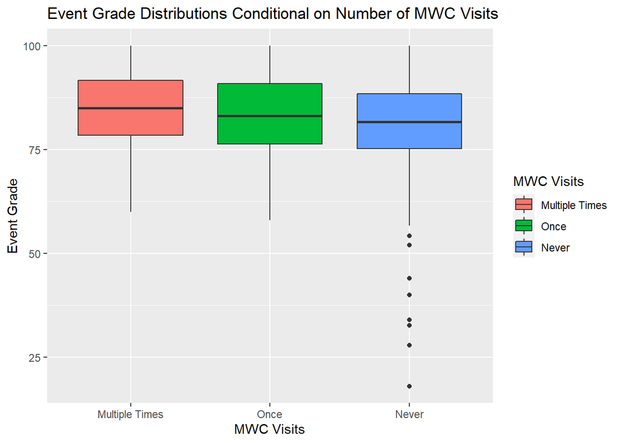

```r
#Event Grade Distributions Conditional on Number of MWC Visits
imputedDataFiltered %>%
  ggplot(aes(y=eventGrade,x=modMWCvisits, fill=modMWCvisits)) +
  geom_boxplot() +
  labs(x = "MWC Visits", y = "Event Grade", fill = "MWC Visits") +
  ggtitle("Event Grade Distributions Conditional on Number of MWC Visits")
```

The following plot displays the distribution of event grades conditional on the number of times students visited the MWC by course.

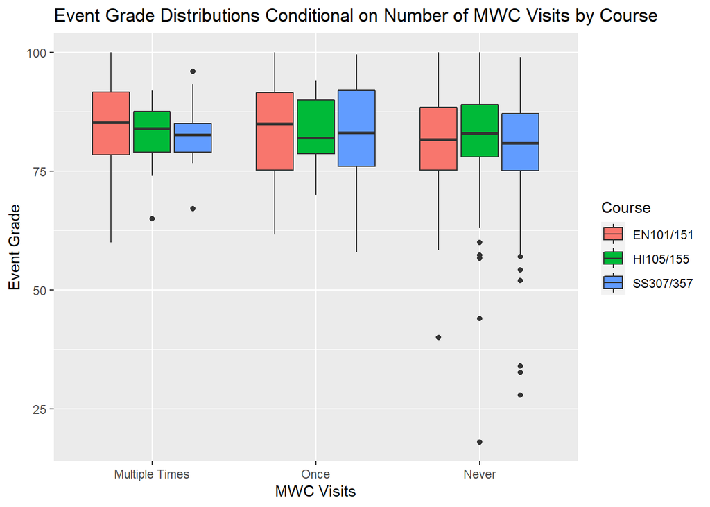

```r
#Event Grade Distributions Conditional on Number of MWC Visits by Course
imputedDataFiltered %>%
  ggplot(aes(y=eventGrade,x=modMWCvisits, fill=course)) +
  geom_boxplot() +
  labs(x = "MWC Visits", y = "Event Grade", fill = "Course") +
  ggtitle("Event Grade Distributions Conditional on Number of MWC Visits by Course")
```

### Propensity Score Matching

The following table displays the amount of observations per treatment by course. The courses represented here are structured such that the variation from section-to-section is minimal. However, the differences between courses is substantial and therefore we will utilize partial exact matching so that all matched students will have taken the same course.

```r
#Subjects by Treatment
table(imputedDataFiltered$modMWCvisits, useNA = "ifany")
```

```
##
## Multiple Times           Once          Never
##             95            207           2366
```

```r
#Subjects by Course
table(imputedDataFiltered$modMWCvisits, imputedDataFiltered$course, useNA = "ifany")
```

```
##
##                  EN101/151 HI105/155 SS307/357
##   Multiple Times        73        11        11
##   Once                 101        29        77
##   Never                942       496       928
```

The first step of this analysis is to estimate the propensity scores. The trips function will estimate three propensity score models (PS1, PS2, PS3) as described below. Note that when specifying the formula the dependent variable, or treatment indicator, is not included. The trips function will replace the dependent variable as it estimates the three logistic regression models.

```r
#Estimating the propensity scores for the three models
formu <- ~ sex + enterAge + race + CEER + satMath + satVrbl + satWrite + actComp + actEng + actMath + actRead + actWrite
visits.tpsa <- trips(imputedDataFiltered, imputedDataFiltered$modMWCvisits, formu)
```

```
## Using logistic regression to estimate propensity scores...
```

```r
#Combined summary of the three logistic regression models
summary(visits.tpsa)
```

|  | Estimate | Std. Error | z value | Pr(>\|z\|) | m1 | Estimate | Std. Error | z value | Pr(>\|z\|) | m2 | Estimate | Std. Error | z value | Pr(>\|z\|) | m3 |
| --- | --- | --- | --- | --- | --- | --- | --- | --- | --- | --- | --- | --- | --- | --- | --- |
| (Intercept) | -2.2868064535 | 1.904356416 | -1.2008290 | 2.298175e-01 |  | -6.4727316493 | 2.690868750 | -2.4054431 | 0.01615287 | * | 3.842165e+00 | 3.383063103 | 1.13570596 | 0.25607964 |  |
| sexM | -0.7259656413 | 0.168656918 | -4.3043929 | 1.674443e-05 | *** | -0.6412863318 | 0.251485687 | -2.5499914 | 0.01077256 | * | -2.367801e-02 | 0.297886852 | -0.07948659 | 0.93664560 |  |
| enterAge | 0.0292987617 | 0.078167275 | 0.3748213 | 7.077934e-01 |  | 0.1137421638 | 0.108182591 | 1.0513906 | 0.29307921 |  | -5.432250e-02 | 0.139496178 | -0.38941926 | 0.69696602 |  |
| raceB | -0.1567424754 | 0.308764158 | -0.5076447 | 6.117026e-01 |  | -0.0697901723 | 0.415147059 | -0.1681095 | 0.86649712 |  | -2.813196e-01 | 0.531475325 | -0.52931833 | 0.59658464 |  |
| raceH | -0.7599317703 | 0.360293699 | -2.1092008 | 3.492725e-02 | * | -1.2954346993 | 0.588090986 | -2.2027794 | 0.02761030 | * | 6.101273e-01 | 0.699095315 | 0.87273840 | 0.38280568 |  |
| raceN | -0.6592705526 | 0.770966522 | -0.8551222 | 3.924835e-01 |  | -0.7189849280 | 1.075073402 | -0.6687775 | 0.50363741 |  | -1.175360e-01 | 1.343532899 | -0.08748275 | 0.93028780 |  |
| raceO | -0.3841879521 | 0.646507888 | -0.5942510 | 5.523443e-01 |  | -0.1157891495 | 0.790448398 | -0.1464854 | 0.88353821 |  | -9.459518e-02 | 1.021900880 | -0.09256787 | 0.92624687 |  |
| raceW | -0.4595108221 | 0.240919863 | -1.9073181 | 5.647940e-02 | . | -0.6536169064 | 0.317286807 | -2.0600192 | 0.03939671 | * | 1.273774e-01 | 0.413171966 | 0.30829157 | 0.75786048 |  |
| CEER | -0.0002958600 | 0.002391952 | -0.1236898 | 9.015609e-01 |  | 0.0054641576 | 0.003330308 | 1.6407365 | 0.10085213 |  | -7.072064e-03 | 0.004427235 | -1.59739996 | 0.11017658 |  |
| satMath | 0.0017329247 | 0.001757222 | 0.9861729 | 3.240483e-01 |  | 0.0024575272 | 0.002616919 | 0.9390918 | 0.34768363 |  | 6.530259e-05 | 0.002870864 | 0.02274667 | 0.98185235 |  |

[output cut: 7 more lines]

The following figure is a triangle plot that depicts the propensity scores from the three models. Since each student has two propensity scores, their scores are connected with a line.

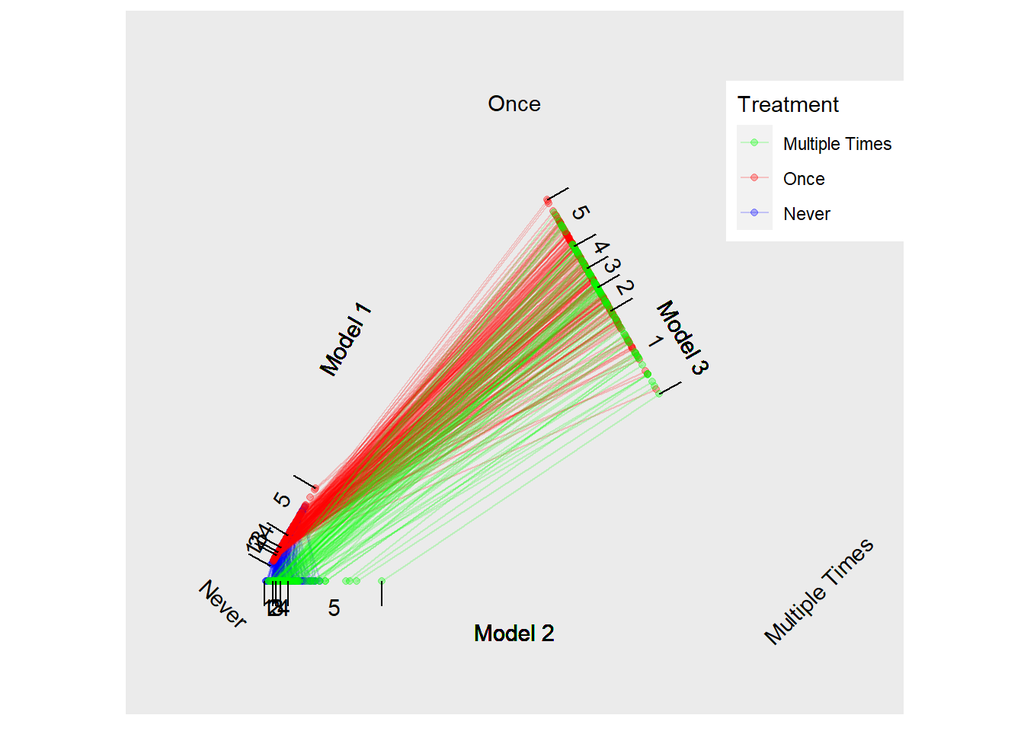

```r
#Triangle Plot
plot(visits.tpsa, sample = c(200))
```

The default for trimatch is to use the maximumTreat method retaining each treatment subject once with those who visited once matched more than once only if the corresponding person who visited multiple times would not be matched otherwise. In the cases below we will use exact matching on the course.

```r
#Default maximumTreat Matching
visits.matched <- trimatch(visits.tpsa, exact = imputedDataFiltered[,c("course")])
```

Setting the method parameter to NULL will result in caliper matching. All matched triplets within the specified caliper are retained. This will result in the largest number of matched triplets.

```r
#Caliper Matching
visits.matched.caliper <- trimatch(visits.tpsa, exact = imputedDataFiltered[,c("course")], method = NULL)
```

Lastly, we will use the OneToN method to retain a 2-to-1-to-n and 3-to-2-n matches.

```r
#2-to-1-to-1 Matching
visits.matched.2to1 <- trimatch(visits.tpsa, exact = imputedDataFiltered[,c("course")], method = OneToN, M1 = 2, M2 = 1)
```

```r
#3-to-2-to-1 Matching
visits.matched.3to2 <- trimatch(visits.tpsa, exact = imputedDataFiltered[,c("course")], method = OneToN, M1 = 3, M2 = 2)
```

## Examining Unmatched Students

The different methods for retaining matched triplets addresses the issue of overrepresentation of treatment units. These methods fall on a spectrum where each treatment unit is used minimally (maximumTreat method) or all units are used (caliper matching). Rosenbaum (2012) suggests testing hypotheses more than once and using multiple methods. Functions to help present and compare the results from multiple methods are provided and discussed below.

The unmatched function will return the rows of students who were not matched. The summary function will provide information about how many students within each group were not matched. As indicated below, the caliper matching will match the most students.

```r
#Unmatched using maximumTreat Matching Method
summary(unmatched(visits.matched))
```

```
## 2260 (84.7%) of 2668 total data points were not matched.
## Unmatched by treatment:
## Multiple Times           Once          Never
##     11 (11.6%)     43 (20.8%)   2206 (93.2%)
```

```r
#Unmatched using Caliper Matching Method
summary(unmatched(visits.matched.caliper))
```

```
## 1754 (65.7%) of 2668 total data points were not matched.
## Unmatched by treatment:
## Multiple Times           Once          Never
##     11 (11.6%)     43 (20.8%)   1700 (71.9%)
```

```r
#Unmatched using 2to1 Matching Method
summary(unmatched(visits.matched.2to1))
```

```
## 2457 (92.1%) of 2668 total data points were not matched.
## Unmatched by treatment:
## Multiple Times           Once          Never
##     17 (17.9%)      149 (72%)   2291 (96.8%)
```

```r
#Unmatched using 3to2 Matching Method
summary(unmatched(visits.matched.3to2))
```

```
## 2369 (88.8%) of 2668 total data points were not matched.
## Unmatched by treatment:
## Multiple Times           Once          Never
##     12 (12.6%)    129 (62.3%)   2228 (94.2%)
```

We can overlay matched triplets on the triangle plot.

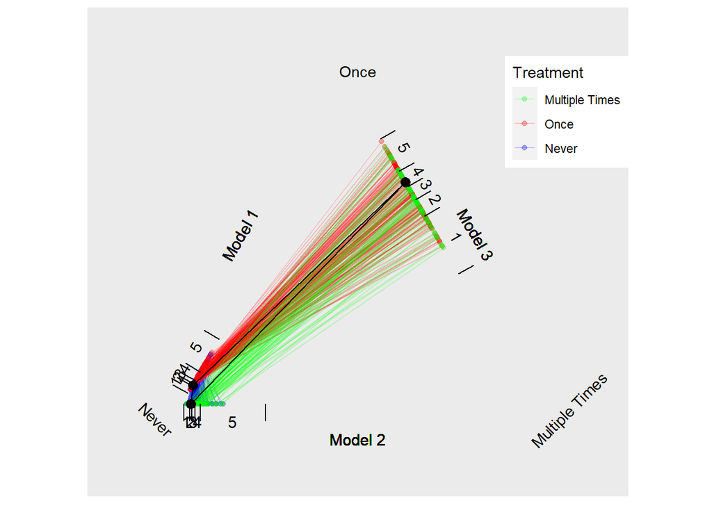

```r
#Triangle Plot
plot(visits.matched, rows=c(1), line.alpha=1, draw.segments=TRUE)
```

## Checking Balance

```r
#Multiple Covariate Balance Plot
#multibalance.plot(visits.tpsa) +
 #ggtitle("Covariate Balance Plot")
```

The following figure is the results of the balance.plot function. This function will provide a bar chart for categorical covariates and box plots for quantitative covariates, individually or in a grid.

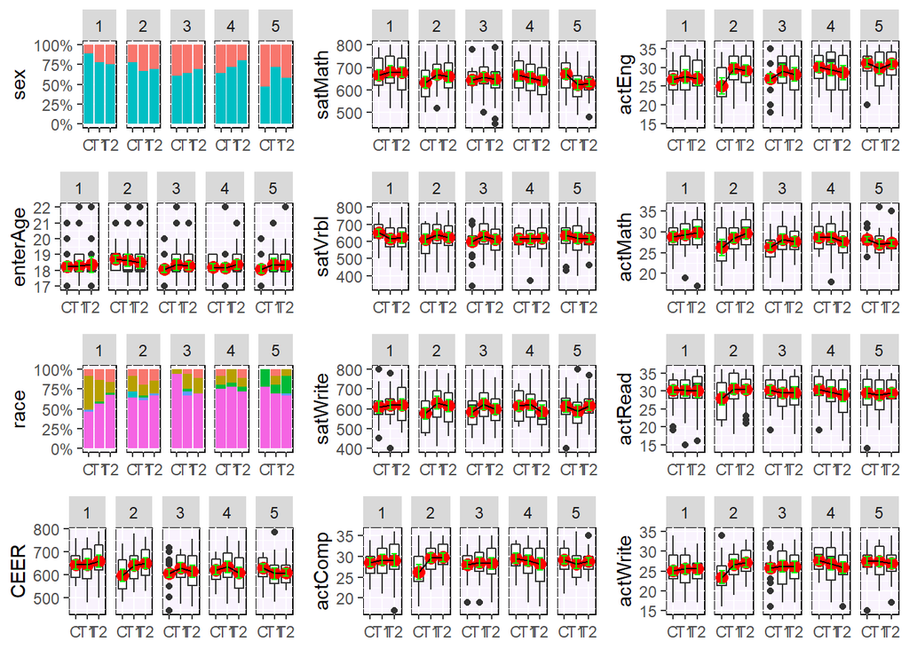

```r
#Grid of Balance Plots
bplots <- balance.plot(visits.matched, imputedDataFiltered[,all.vars(formu)],
                       legend.position = 'none', x.axis.labels = c('M','O','N'), x.axis.angle = 0)

plot(bplots, cols = 3, byrow = FALSE)
```

## Estimating Effects of Visits on Student Grades

In this section we seek to compare our outcome of interest, event grade, across the matches. A custom merge function is provided to merge an outcome from the original data frame to the results of trimatch. This merge function will add three columns with the outcome for each of the three groups

```r
#Merging outcome from the original df and the results of trimatch
matched.out <- merge(visits.matched, imputedDataFiltered$eventGrade)
head(matched.out)
```

|  | Once | Multiple Times | Never | D.m3 | D.m2 | D.m1 | Dtotal | Once.out | Multiple Times.out | Never.out |
| --- | --- | --- | --- | --- | --- | --- | --- | --- | --- | --- |
| 1 | 2353 | 1748 | 2236 | 0.0002803556 | 0.0010338222 | 0.0001012286 | 0.001415406 | 95.2 | 81.6 | 91.6 |
| 2 | 1952 | 2272 | 2432 | 0.0008541927 | 0.0009034867 | 0.0006300444 | 0.002387724 | 78.4 | 95.2 | 81.6 |
| 3 | 2157 | 2440 | 2518 | 0.0009710818 | 0.0139363590 | 0.0024893198 | 0.017396761 | 91.6 | 78.4 | 88.4 |
| 4 | 2081 | 1996 | 1670 | 0.0060734880 | 0.0119400620 | 0.0011752881 | 0.019188838 | 71.6 | 63.6 | 78.4 |
| 5 | 953 | 1619 | 2334 | 0.0055995703 | 0.0068200953 | 0.0067874927 | 0.019207158 | 91.5 | 88.4 | 60.0 |
| 6 | 2226 | 2119 | 1765 | 0.0143110593 | 0.0048230314 | 0.0064058092 | 0.025539900 | 68.4 | 81.6 | 88.4 |

Although the merge function is convenient for conducting one’s own analysis, the summary function will perform the most common analyses including Friedman Rank Sum test and the repeated measures ANOVA. If either of those tests produce a p-value less than the specified threshold of 0.05 by default, then the summary function will also perform and return the Wilcoxon signed rank test and three separate dependent sample t-tests (see Austin [2010] for discussion of dependent versus independent t-tests).

# Default Matching Model

```r
#Summary output from default matching model
s1 <- summary(visits.matched, imputedDataFiltered$eventGrade)
```

```r
#Percent matched from default matching model
s1$PercentMatched
```

```
## Multiple Times           Once          Never
##     0.88421053     0.79227053     0.06762468
```

```r
#Friedman Test from default matching model
s1$friedman.test
```

```
##
##  Friedman rank sum test
##
## data:  Outcome and Treatment and ID
## Friedman chi-squared = 0.96361, df = 2, p-value = 0.6177
```

```r
#ANOVA from default matching model
s1$rmanova
```

```
## $ANOVA
##      Effect DFn DFd         F         p p<.05         ges
## 2 Treatment   2 360 0.3824853 0.6824408       0.001340138
##
## $`Mauchly's Test for Sphericity`
##      Effect        W         p p<.05
## 2 Treatment 0.996681 0.7426381
##
## $`Sphericity Corrections`
##      Effect      GGe     p[GG] p[GG]<.05      HFe     p[HF] p[HF]<.05
## 2 Treatment 0.996692 0.6817474           1.007835 0.6824408
```

Note that for this model we do not meet the threshold with a p-value greater than 0.05, and therefore the summary function does not return the Wilcoxon signed rank test and three separate dependent sample t-tests.

# Caliper Matching Model

```r
#Summary output from caliper matching model
s2 <- summary(visits.matched.caliper, imputedDataFiltered$eventGrade)
```

```r
#Percent matched from caliper matching model
s2$PercentMatched
```

```
## Multiple Times           Once          Never
##      0.8842105      0.7922705      0.2814877
```

```r
#Friedman Test from caliper matching model
s2$friedman.test
```

```
##
##  Friedman rank sum test
##
## data:  Outcome and Treatment and ID
## Friedman chi-squared = 34.092, df = 2, p-value = 3.954e-08
```

```r
#ANOVA from caliper matching model
s2$rmanova
```

```
## $ANOVA
##      Effect DFn  DFd        F            p p<.05         ges
## 2 Treatment   2 7380 27.76785 9.676641e-13     * 0.004969381
##
## $`Mauchly's Test for Sphericity`
##      Effect         W         p p<.05
## 2 Treatment 0.9991632 0.2134926
##
## $`Sphericity Corrections`
##      Effect       GGe        p[GG] p[GG]<.05      HFe        p[HF] p[HF]<.05
## 2 Treatment 0.9991639 9.870598e-13         * 0.999705 9.744623e-13         *
```

```r
#Pairwise Wilcox Test from caliper matching model
s2$pairwise.wilcox.test
```

```
##
##  Pairwise comparisons using Wilcoxon signed rank test with continuity correction
##
## data:  out$Outcome and out$Treatment
##
##                    Once.out Multiple Times.out
## Multiple Times.out 4.3e-11  -
## Never.out          1        1.9e-07
##
## P value adjustment method: bonferroni
```

```r
#T-tests from caliper matching model
s2$t.tests
```

|  | Treatments | t | df | p.value | sig | mean.diff | ci.min | ci.max |
| --- | --- | --- | --- | --- | --- | --- | --- | --- |
| 1 | Once.out-Multiple Times.out | -6.5244279 | 3690 | 7.754487e-11 | *** | -1.35988350 | -1.7685319 | -0.9512351 |
| 2 | Once.out-Never.out | -0.1048288 | 3690 | 9.165173e-01 |  | -0.02220807 | -0.4375644 | 0.3931482 |
| 3 | Multiple Times.out-Never.out | 6.4709913 | 3690 | 1.101590e-10 | *** | 1.33767543 | 0.9323811 | 1.7429697 |

Note that for this model we do meet the threshold with a p-value less than 0.05, and therefore the summary function does return the Wilcoxon signed rank test and three separate dependent sample t-tests.

# 2-to-1 Model

```r
#Summary output from 2-to-1 matching model
s3 <- summary(visits.matched.2to1, imputedDataFiltered$eventGrade)
```

```r
#Percent matched from 2-to-1 matching model
s3$PercentMatched
```

```
## Multiple Times           Once          Never
##     0.82105263     0.28019324     0.03169907
```

```r
#Friedman Test from 2-to-1 matching model
s3$friedman.test
```

```
##
##  Friedman rank sum test
##
## data:  Outcome and Treatment and ID
## Friedman chi-squared = 0.12838, df = 2, p-value = 0.9378
```

```r
#ANOVA from 2-to-1 matching model
s3$rmanova
```

```
## $ANOVA
##      Effect DFn DFd          F         p p<.05          ges
## 2 Treatment   2 154 0.06558838 0.9365424       0.0005086553
##
## $`Mauchly's Test for Sphericity`
##      Effect         W         p p<.05
## 2 Treatment 0.9927398 0.7581344
##
## $`Sphericity Corrections`
##      Effect       GGe     p[GG] p[GG]<.05      HFe     p[HF] p[HF]<.05
## 2 Treatment 0.9927921 0.9355321           1.018975 0.9365424
```

Note that for this model we do not meet the threshold with a p-value greater than 0.05, and therefore the summary function does not return the Wilcoxon signed rank test and three separate dependent sample t-tests.

# 3-to-2 Model

```r
#Summary output from 3-to-2 matching model
s4 <- summary(visits.matched.3to2, imputedDataFiltered$eventGrade)
```

```r
#Percent matched from 3-to-2  matching model
s4$PercentMatched
```

```
## Multiple Times           Once          Never
##     0.87368421     0.37681159     0.05832629
```

```r
#Friedman Test from 3-to-2 matching model
s4$friedman.test
```

```
##
##  Friedman rank sum test
##
## data:  Outcome and Treatment and ID
## Friedman chi-squared = 0.17786, df = 2, p-value = 0.9149
```

```r
#ANOVA from 3-to-2  matching model
s4$rmanova
```

```
## $ANOVA
##      Effect DFn DFd         F         p p<.05        ges
## 2 Treatment   2 290 0.2988975 0.7418636       0.00129525
##
## $`Mauchly's Test for Sphericity`
##      Effect         W         p p<.05
## 2 Treatment 0.9963474 0.7683845
##
## $`Sphericity Corrections`
##      Effect       GGe    p[GG] p[GG]<.05      HFe     p[HF] p[HF]<.05
## 2 Treatment 0.9963607 0.741067           1.010219 0.7418636
```

Note that for this model we do not meet the threshold with a p-value greater than 0.05, and therefore the summary function does not return the Wilcoxon signed rank test and three separate dependent sample t-tests.

## Loess Plots

Another useful visualization for presenting the results is the Loess plot. In the figures below we plot the propensity scores on the x-axis and the outcome (grade) on the y-axis. A Loess regression line is then overlaid. Since there are three propensity scorescales, the plot.loess3 function will use the propensity scores from the model predicting treatment one (once) from treatment two (multiple times). Propensity scores for the control group (never) are then imputed by taking the mean of the propensity scores of the two treatment units that control was matched to. It should be noted that if a control unit is matched to two different sets of treatment units, then that control unit will have two propensity scores. Which propensity score scale is utilized can be explicitly specified using the model parameter.

# Default Method

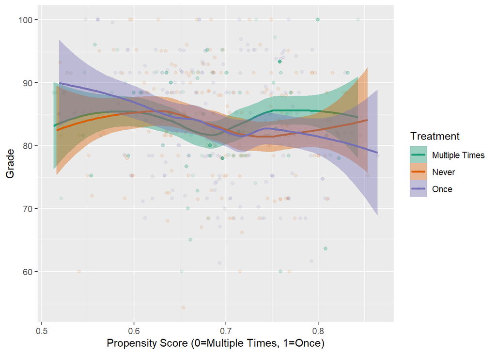

```r
#Loess Plot Default Method
loess3.plot(visits.matched, imputedDataFiltered$eventGrade, ylab='Grade')
```

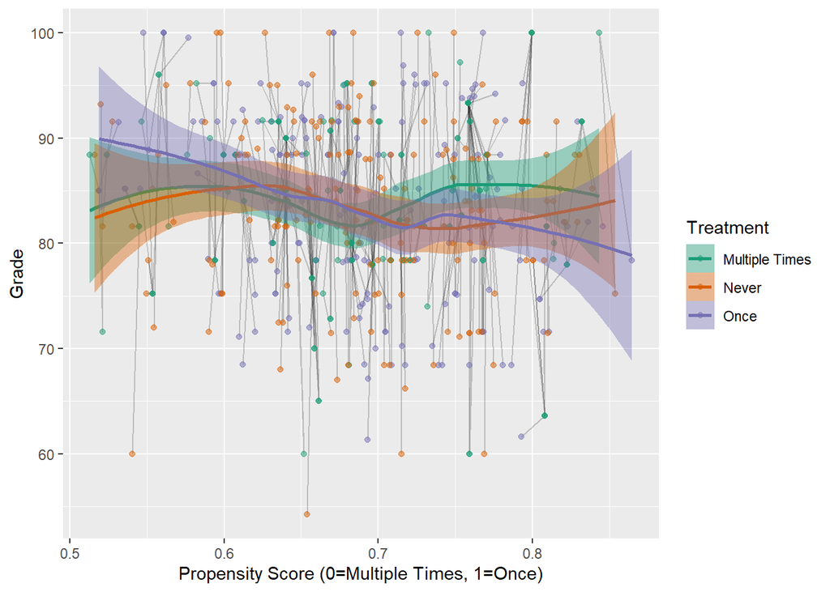

```r
# Draw lines connecting each matched triplet
loess3.plot(visits.matched, imputedDataFiltered$eventGrade, ylab='Grade', points.alpha=.5, plot.connections=TRUE)
```

# Caliper Method

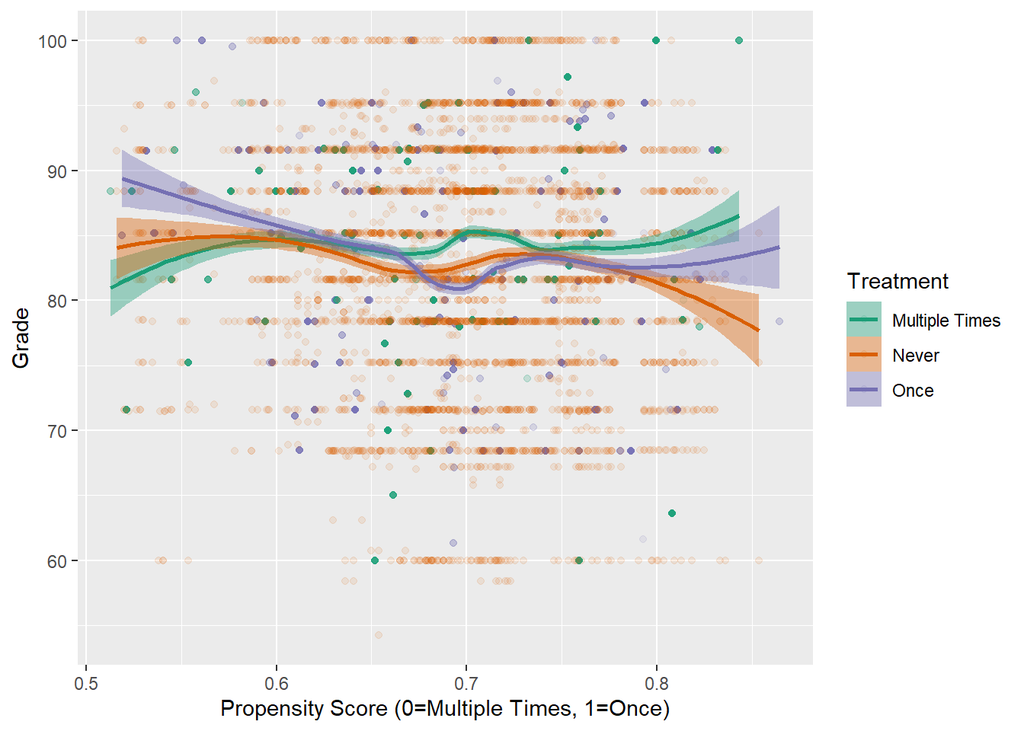

```r
#Loess Plot for the Caliper Matching Method
loess3.plot(visits.matched.caliper, imputedDataFiltered$eventGrade, ylab='Grade', points.alpha=.1, method='loess')
```

# 2-to-1 Method

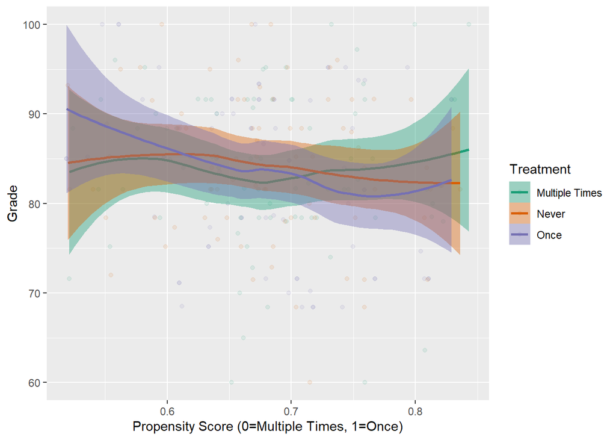

```r
#Loess Plot for the 2-to-1 Matching Method
loess3.plot(visits.matched.2to1, imputedDataFiltered$eventGrade, ylab='Grade', span=.9)
```

# 3-to-2 Method

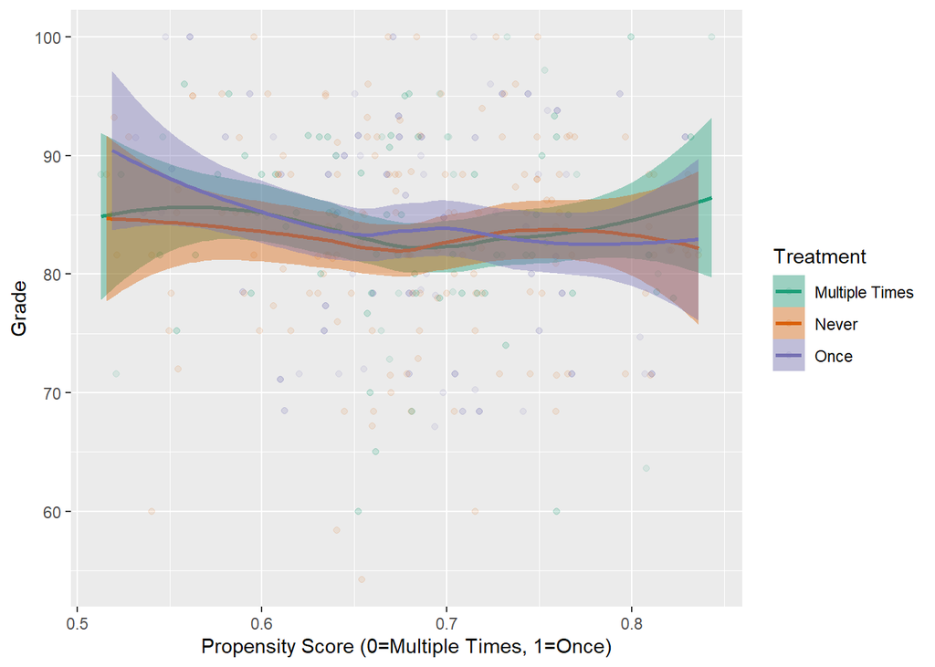

```r
#Loess plot for the 3-to-2 Matching Method
loess3.plot(visits.matched.3to2, imputedDataFiltered$eventGrade, ylab='Grade', span=.9)
```

# Boxplot of Differences

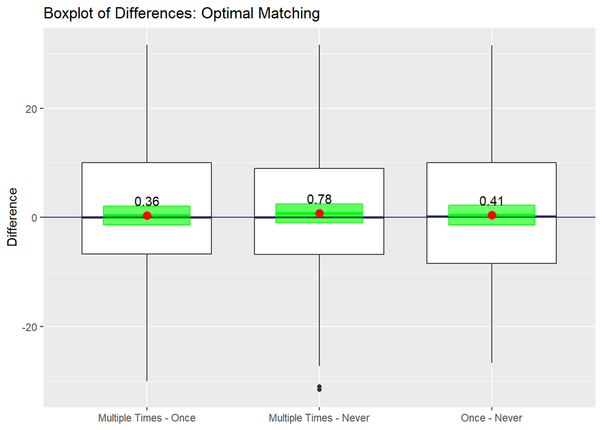

```r
#Boxplot of Differences Optimal Matching Method
boxdiff.plot(visits.matched, imputedDataFiltered$eventGrade,
             ordering=c('Multiple Times','Once','Never')) +
  ggtitle('Boxplot of Differences: Optimal Matching')
```

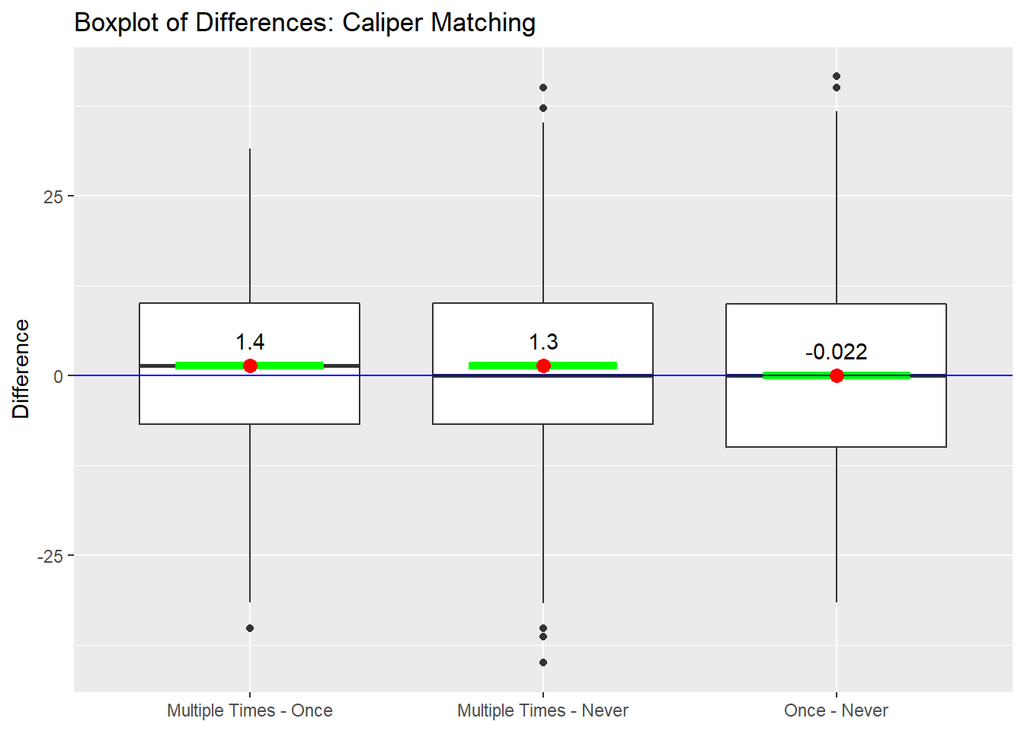

```r
#Boxplot of Differences Caliper Matching Method
boxdiff.plot(visits.matched.caliper, imputedDataFiltered$eventGrade,
             ordering=c('Multiple Times','Once','Never')) +
  ggtitle('Boxplot of Differences: Caliper Matching')
```

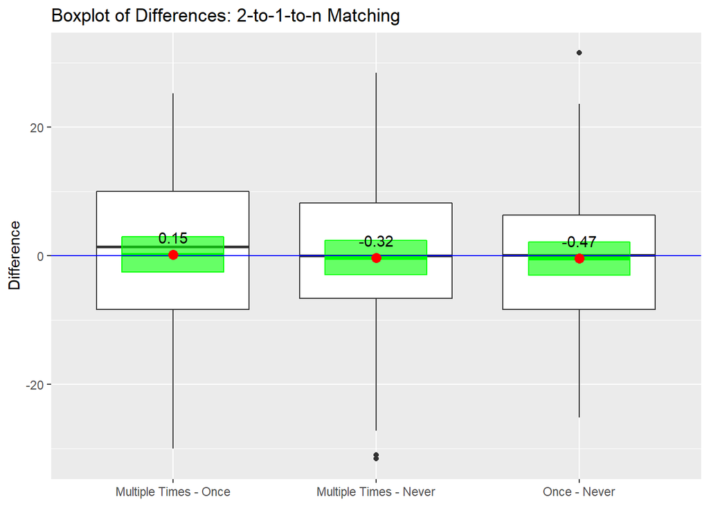

```r
#Boxplot of Differences 2-to-1-to-n Matching
boxdiff.plot(visits.matched.2to1, imputedDataFiltered$eventGrade,
             ordering=c('Multiple Times','Once','Never')) +
  ggtitle('Boxplot of Differences: 2-to-1-to-n Matching')
```

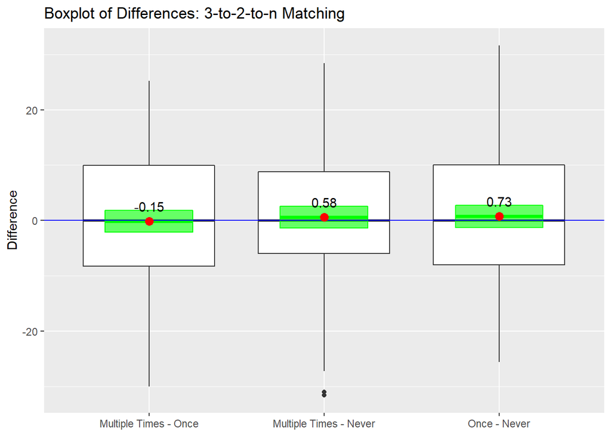

```r
#Boxplot of Differences 3-to-2-to-n Matching
boxdiff.plot(visits.matched.3to2, imputedDataFiltered$eventGrade,
             ordering=c('Multiple Times','Once','Never')) +
  ggtitle('Boxplot of Differences: 3-to-2-to-n Matching')
```

```r
#Summary
print(print('Optimal'=s1, 'Caliper'=s2, '2-to-1'=s3, '3-to-2'=s4), row.names=FALSE)
```

```
##   Method Friedman.chi2   Friedman.p       rmANOVA.F    rmANOVA.p
##  Optimal     0.9636099 6.176675e-01      0.38248527 6.824408e-01
##  Caliper    34.0920592 3.953697e-08 *** 27.76784895 9.676641e-13 ***
##   2-to-1     0.1283784 9.378276e-01      0.06558838 9.365424e-01
##   3-to-2     0.1778584 9.149103e-01      0.29889752 7.418636e-01
```

## Sensitivity Analysis

```r
psens(matched.out$Once.out, matched.out$Never.out, Gamma=2, GammaInc=0.1)
```

```
##
##  Rosenbaum Sensitivity Test for Wilcoxon Signed Rank P-Value
##
## Unconfounded estimate ....  0.2852
##
##  Gamma Lower bound Upper bound
##    1.0      0.2852      0.2852
##    1.1      0.1328      0.4910
##    1.2      0.0532      0.6825
##    1.3      0.0189      0.8246
##    1.4      0.0060      0.9129
##    1.5      0.0018      0.9605
##    1.6      0.0005      0.9834
##    1.7      0.0001      0.9935
##    1.8      0.0000      0.9976
##    1.9      0.0000      0.9992
##    2.0      0.0000      0.9997
##
##  Note: Gamma is Odds of Differential Assignment To
##  Treatment Due to Unobserved Factors
##
```

```r
matched.out <- matched.out %>%
  rename('Multiple_Times.out' = 'Multiple Times.out')
psens(matched.out$Multiple_Times.out, matched.out$Never.out, Gamma=2, GammaInc=0.1)
```

```
##
##  Rosenbaum Sensitivity Test for Wilcoxon Signed Rank P-Value
##
## Unconfounded estimate ....  0.2086
##
##  Gamma Lower bound Upper bound
##    1.0      0.2086      0.2086
##    1.1      0.0901      0.3882
##    1.2      0.0340      0.5779
##    1.3      0.0115      0.7385
##    1.4      0.0035      0.8530
##    1.5      0.0010      0.9240
##    1.6      0.0003      0.9635
##    1.7      0.0001      0.9835
##    1.8      0.0000      0.9930
##    1.9      0.0000      0.9971
##    2.0      0.0000      0.9989
##
##  Note: Gamma is Odds of Differential Assignment To
##  Treatment Due to Unobserved Factors
##
```

```r
psens(matched.out$Once.out, matched.out$Multiple_Times.out, Gamma=2, GammaInc=0.1)
```

```
##
##  Rosenbaum Sensitivity Test for Wilcoxon Signed Rank P-Value
##
## Unconfounded estimate ....  0.7694
##
##  Gamma Lower bound Upper bound
##    1.0      0.7694      0.7694
##    1.1      0.5787      0.8992
##    1.2      0.3850      0.9618
##    1.3      0.2282      0.9872
##    1.4      0.1221      0.9961
##    1.5      0.0598      0.9989
##    1.6      0.0271      0.9997
##    1.7      0.0115      0.9999
##    1.8      0.0046      1.0000
##    1.9      0.0018      1.0000
##    2.0      0.0006      1.0000
##
##  Note: Gamma is Odds of Differential Assignment To
##  Treatment Due to Unobserved Factors
##
```